# Non-parametric tests

12 Jan 2017

## Inhoud

## Nonparametric tests

## Parametric vs Nonparametric

| Attribute | Parametric | Nonparametric |
| --- | --- | --- |
| distribution | normaly distributed | any distribution |
| sampling | random sample | random sample |
| sensitivity to outliers | yes | no |
| works with | large data sets | small and large data sets |
| speed | fast | slow |

## Ranking

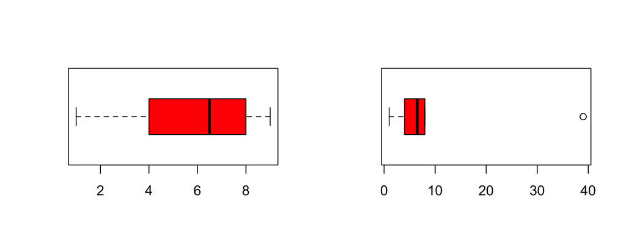

```r
x = c(1, 4, 6, 7, 8, 9)
y = c(1, 4, 6, 7, 8, 39)

layout(matrix(1:2, 1, 2))
boxplot(x, horizontal=T, col='red')
boxplot(y, horizontal=T, col='red')
```

```r
rbind(rx = rank(x), ry = rank(y))
```

```
##    [,1] [,2] [,3] [,4] [,5] [,6]
## rx    1    2    3    4    5    6
## ry    1    2    3    4    5    6
```

## Ties

```r
x = c(1, 4, 6, 7, 8, 8, 4, 7, 9)

rbind(x, ordered = sort(x), non.tied.rank = 1:length(x), ranked = rank(sort(x)))
```

```
##               [,1] [,2] [,3] [,4] [,5] [,6] [,7] [,8] [,9]
## x                1  4.0  6.0    7  8.0  8.0  4.0  7.0    9
## ordered          1  4.0  4.0    6  7.0  7.0  8.0  8.0    9
## non.tied.rank    1  2.0  3.0    4  5.0  6.0  7.0  8.0    9
## ranked           1  2.5  2.5    4  5.5  5.5  7.5  7.5    9
```

\[\frac{2 + 3}{2} = 2.5, \frac{5 + 6}{2} = 5.5, \frac{7 + 8}{2} = 7.5\]

## Procedure

1. Assumption: independent random samples.
2. Hypothesis:  
   \(H_0\) : equal population distributions (implies equal mean ranking)  
   \(H_A\) : unequal mean ranking (two sided)  
   \(H_A\) : higher mean ranking for one group.
3. Test statistic is difference between mean or sum of ranking.
4. Standardise test statistic
5. Calculate *P*-value one or two sided.
6. Conclude to reject \(H_0\) if \(p < \alpha\).

## Wilcoxon rank-sum test

Independent 2 samples

## Wilcoxon rank-sum test

[figure not shown]

Developed by [Frank Wilcoxon](http://en.wikipedia.org/wiki/Frank_Wilcoxon) the rank-sum test is a [nonparametric](http://en.wikipedia.org/wiki/Nonparametric_statistics) alternative to the independent samples t-test.

By first ranking \(x\) and then sum these ranks per group one would expect, under the null hypothesis, equal values for both groups.

After standardising this difference one can test using a standard normal distribution.

## Simulate data

```r
n      = 20
factor = rep(c("Ecstasy","Alcohol"),each=n/2)
dummy  = ifelse(factor == "Ecstacy", 0, 1)
b.0    = 23
b.1    = 5
error  = rnorm(n, 0, 1.7)
depres = b.0 + b.1*dummy + error
depres = round(depres)

data <- data.frame(factor, depres)

## add the ranks
data$R <- rank(data$depres)
```

## Example

|  | factor | depres | R |
| --- | --- | --- | --- |
| 1 | Ecstasy | 29 | 13 |
| 2 | Ecstasy | 30 | 18 |
| 3 | Ecstasy | 26 | 2.5 |
| 4 | Ecstasy | 28 | 8.5 |
| 5 | Ecstasy | 29 | 13 |
| 6 | Ecstasy | 30 | 18 |
| 7 | Ecstasy | 29 | 13 |
| 8 | Ecstasy | 27 | 5 |
| 9 | Ecstasy | 29 | 13 |
| 10 | Ecstasy | 30 | 18 |

[output cut: 10 more lines]

## Calculate the sum of ranks per group

```r
R <- aggregate(R ~ factor, data, sum)
R
```

```
##    factor   R
## 1 Alcohol  88
## 2 Ecstasy 122
```

## So W is the lowest

\[W=min\left(\sum{R_1},\sum{R_2}\right)\]

```r
W <- min(R$R)
W
```

```
## [1] 88
```

## Standardise W

To calculate the Z score we need to standardise the W. To do so we need the mean W and the standard error of W.

For this we need the sample sizes for each group.

```r
n <- aggregate(R ~ factor, data, length)

n.1 = n$R[1]
n.2 = n$R[2]

cbind(n.1, n.2)
```

```
##      n.1 n.2
## [1,]  10  10
```

## Mean W

\[\bar{W}_s=\frac{n_1(n_1+n_2+1)}{2}\]

```r
W.mean = (n.1*(n.1+n.2+1))/2
W.mean
```

```
## [1] 105
```

## SE W

\[{SE}_{\bar{W}_s}=\sqrt{ \frac{n_1 n_2 (n_1+n_2+1)}{12} }\]

```r
W.se = sqrt((n.1*n.2*(n.1+n.2+1))/12)
W.se
```

```
## [1] 13.22876
```

## Calculate Z

\[z = \frac{W - \bar{W}}{{SE}_W}\]

Which looks a lot like

\[\frac{X - \bar{X}}{{SE}_X} \text{or} \frac{b - \mu_{b}}{{SE}_b} \]

```r
z = (W - W.mean) / W.se
z
```

```
## [1] -1.285079
```

## Test for significance 1 sided

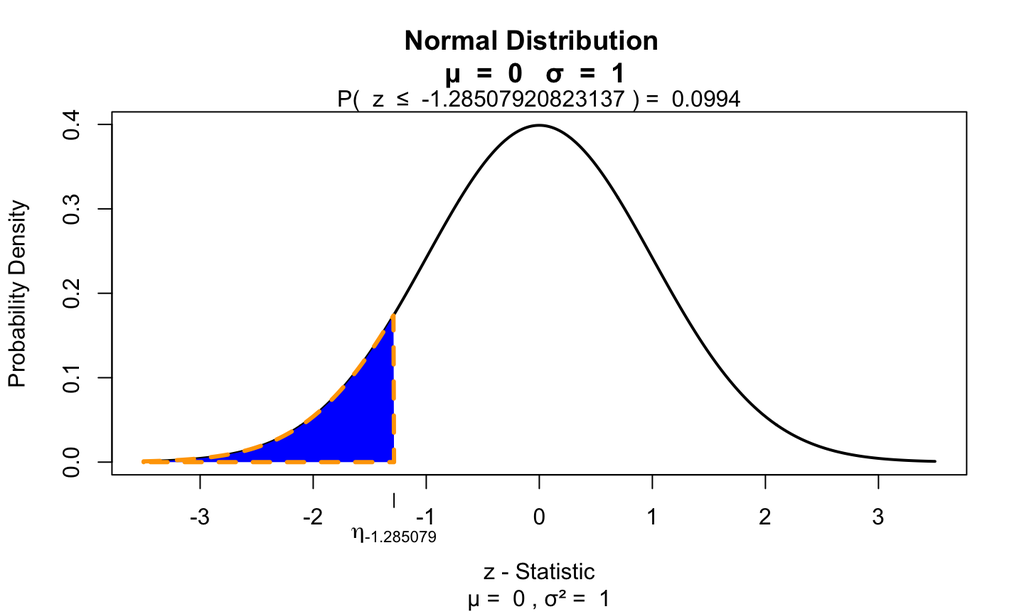

```r
if(!"visualize" %in% installed.packages()){ install.packages("visualize") }
library("visualize")

visualize.norm(z, section="lower")
```

## Test for significance 2 sided

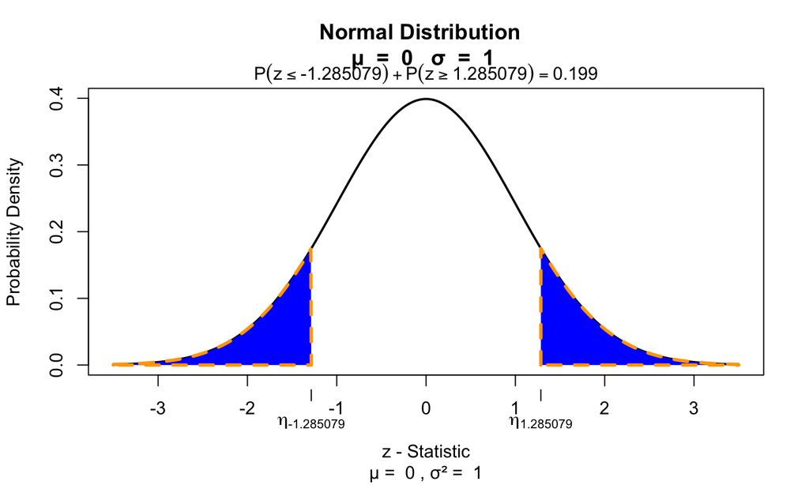

```r
visualize.norm(c(z,-z), section="tails")
```

## Effect size

\[r = \frac{z}{\sqrt{N}}\]

```r
N = sum(n$R)
r = z / sqrt(N)
r
```

```
## [1] -0.2873524
```

## Mann–Whitney test

\[U = n_1 n_2 + \frac{n_1 (n_1 + 1)}{2} - R_1\]

```r
U = (n.1*n.2)+(n.1*(n.1+1))/2-R$R[1]
U
```

```
## [1] 67
```

## \(\bar{U}\) and \({SE}_U\) for non tied ranks

\[\bar{U} = \frac{n_1 n_2}{2}\]

```r
(n.1*n.2)/2
```

```
## [1] 50
```

\[{SE}_U = \sqrt{\frac{n_1 n_2 (n_1 + n_2 + 1)}{12}}\]

```r
sqrt((n.1*n.2*(n.1+n.2+1))/12)
```

```
## [1] 13.22876
```

## Wilcoxon signed-rank test

Paired 2 samples

## Wilcoxon signed-rank test

[figure not shown]

The Wilcoxon signed-rank test is a nonparametric alternative to the paired samples t-test. It assigns + or - signs to the difference between two repeated measures. By ranking the differences and summing these ranks for the positive group, the null hypothesis is tested that both positive and negative differences are equal.

## Simulate data

```r
n      = 20
factor = rep(c("Ecstasy","Alcohol"),each=n/2)
dummy  = ifelse(factor == "Ecstacy", 0, 1)
b.0    = 23
b.1    = 5
error  = rnorm(n, 0, 1.7)
depres = b.0 + b.1*dummy + error
depres = round(depres)

data <- data.frame(factor, depres)

Ecstasy <- subset(data, factor=="Ecstasy")$depres
Alcohol <- subset(data, factor=="Alcohol")$depres

data <- data.frame(Ecstasy, Alcohol)
```

## Example

|  | Ecstasy | Alcohol |
| --- | --- | --- |
| 1 | 29 | 28 |
| 2 | 25 | 28 |
| 3 | 28 | 27 |
| 4 | 27 | 27 |
| 5 | 29 | 28 |
| 6 | 28 | 28 |
| 7 | 28 | 26 |
| 8 | 29 | 27 |
| 9 | 29 | 30 |
| 10 | 28 | 28 |

## Calculate T

```r
# Calculate difference in scores between first and second measure
data$difference = data$Ecstasy - data$Alcohol

# Calculate difference in scores between first and second measure
data$abs.difference = abs(data$Ecstasy - data$Alcohol)

# Create rank variable with place holder NA
data$rank <- NA

# Rank only the difference scores
data[which(data$difference != 0),'rank'] <- rank(data[which(data$difference != 0),
                                                      'abs.difference'])

# Assign a '+' or a '-' to those values
data$sign = sign(data$Ecstasy - data$Alcohol)

# Add positive and negative rank to     test  if    else
data$rank_pos = with(data, ifelse(sign ==  1, rank, 0   ))
data$rank_neg = with(data, ifelse(sign == -1, rank, 0   ))
```

## The data

|  | Ecstasy | Alcohol | difference | abs.difference | rank | sign | rank_pos | rank_neg |
| --- | --- | --- | --- | --- | --- | --- | --- | --- |
| 1 | 29 | 28 | 1 | 1 | 2.5 | 1 | 2.5 | 0 |
| 2 | 25 | 28 | -3 | 3 | 7 | -1 | 0 | 7 |
| 3 | 28 | 27 | 1 | 1 | 2.5 | 1 | 2.5 | 0 |
| 4 | 27 | 27 | 0 | 0 |  | 0 | 0 | 0 |
| 5 | 29 | 28 | 1 | 1 | 2.5 | 1 | 2.5 | 0 |
| 6 | 28 | 28 | 0 | 0 |  | 0 | 0 | 0 |
| 7 | 28 | 26 | 2 | 2 | 5.5 | 1 | 5.5 | 0 |
| 8 | 29 | 27 | 2 | 2 | 5.5 | 1 | 5.5 | 0 |
| 9 | 29 | 30 | -1 | 1 | 2.5 | -1 | 0 | 2.5 |
| 10 | 28 | 28 | 0 | 0 |  | 0 | 0 | 0 |

## Calculate \(T_+\)

```r
# Calculate the sum of the positive ranks
T_pos = sum(data$rank_pos)
T_pos
```

```
## [1] 18.5
```

```r
# Calculate N without 0 (no differences).
n = sum(abs(data$sign))
n
```

```
## [1] 7
```

## Calculate \(\bar{T}\) and \({SE}_{T}\)

\[\bar{T} = \frac{n(n+1)}{4}\]

```r
T_mean = (n*(n+1))/4
T_mean
```

```
## [1] 14
```

\[{SE}_{T} = \sqrt{\frac{n(n+1)(2n+1)}{24}}\]

```r
SE_T = sqrt( (n*(n+1)*(2*n+1)) / 24 )
```

## Calculate Z

\[z = \frac{T_+ - \bar{T}}{{SE}_T}\]

```r
z = (T_pos - T_mean)/SE_T
z
```

```
## [1] 0.7606388
```

## Test for significance

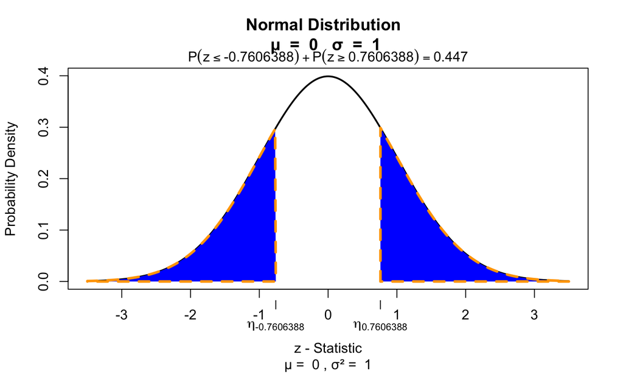

```r
visualize.norm(c(z,-z), section="tails")
```

## Effect size

\[r = \frac{z}{\sqrt{N}}\]

Here \(N\) is the number of observations.

```r
N = 20
r = z / sqrt(N)
r
```

```
## [1] 0.170084
```

## Kruskal–Wallis test

Independent >2 samples

## Kruskal–Wallis test

[figure not shown]

Created by [William Henry Kruskal](http://en.wikipedia.org/wiki/William_Kruskal) (L) and [Wilson Allen Wallis](http://en.wikipedia.org/wiki/W._Allen_Wallis) (R), the Kruskal-Wallis test is a nonparametric alternative to the independent one-way ANOVA.

The Kruskal-Wallis test essentially subtracts the expected mean ranking from the calculated oberved mean ranking, which is \(\chi^2\) distributed.

## Simulate data

```r
n      = 30
factor = rep(c("ecstasy","alcohol","control"), each=n/3)

dummy.1 = ifelse(factor == "alcohol", 1, 0)
dummy.2 = ifelse(factor == "ecstasy", 1, 0)
b.0     = 23
b.1     = 0
b.2     = 0
error   = rnorm(n, 0, 1.7)

# Model
depres  = b.0 + b.1*dummy.1 + b.2*dummy.2 + error
depres  = round(depres)

data <- data.frame(factor, depres)
```

## Assign ranks

```r
# Assign ranks
data$ranks = rank(data$depres)
```

## The data

|  | factor | depres | ranks |
| --- | --- | --- | --- |
| 1 | ecstasy | 22 | 9.5 |
| 2 | ecstasy | 22 | 9.5 |
| 3 | ecstasy | 24 | 23.5 |
| 4 | ecstasy | 25 | 27.5 |
| 5 | ecstasy | 21 | 3 |
| 6 | ecstasy | 24 | 23.5 |
| 7 | ecstasy | 21 | 3 |
| 8 | ecstasy | 23 | 17 |
| 9 | ecstasy | 21 | 3 |
| 10 | ecstasy | 23 | 17 |

[output cut: 20 more lines]

## Calculate H

\[H = \frac{12}{N(N+1)} \sum_{i=1}^k \frac{R_i^2}{n_i} - 3(N+1)\]

- \(N\) total sample size
- \(n_i\) sample size per group
- \(k\) number of groups
- \(R_i\) rank sums per group

## Calculate H

```r
# Now we need the sum of the ranks per group.
R.i = aggregate(ranks ~ factor, data = data, sum)$ranks
R.i
```

```
## [1] 207.0 121.5 136.5
```

```r
# De total sample size N is:
N = nrow(data)

# And the sample size per group is n_i:
n.i = aggregate(depres ~ factor, data=data, length)$depres
n.i
```

```
## [1] 10 10 10
```

## Calculate H

\[H = \frac{12}{N(N+1)} \sum_{i=1}^k \frac{R_i^2}{n_i} - 3(N+1)\]

```r
H = ( 12/(N*(N+1)) ) * sum(R.i^2/n.i) - 3*(N+1)
H
```

```
## [1] 5.37871
```

And the degrees of freedom

```r
k  = 3
df = k - 1
```

## Test for significance

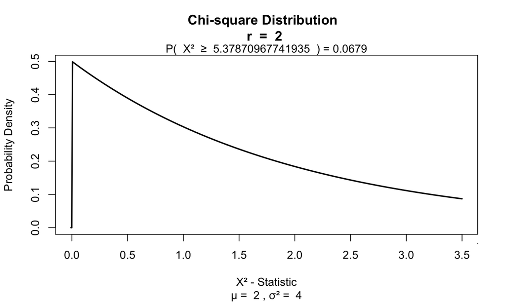

```r
visualize.chisq(H, df, section="upper")
```

## Friedman’s ANOVA

Paired >2 samples

## Friedman’s ANOVA

[figure not shown]

Created by [William Frederick Friedman](http://en.wikipedia.org/wiki/William_F._Friedman) the Friedman's ANOVA is a nonparametric alternative to the repeated one-way ANOVA.

Just like the Kruskal-Wallis test, Friedman's ANOVA, subtracts the expected mean ranking from the calculated oberved mean ranking, which is also \(\chi^2\) distributed.

## Simulate data

```r
n      = 30
factor = rep(c("ecstasy","alcohol","control"), each=n/3)

dummy.1 = ifelse(factor == "alcohol", 1, 0)
dummy.2 = ifelse(factor == "ecstasy", 1, 0)
b.0     = 23
b.1     = 0
b.2     = 0
error   = rnorm(n, 0, 1.7)

# Model
depres  = b.0 + b.1*dummy.1 + b.2*dummy.2 + error
depres  = round(depres)

data <- data.frame(factor, depres)
```

## Simulate data

```r
ecstasy <- subset(data, factor=="ecstasy")$depres
alcohol <- subset(data, factor=="alcohol")$depres
control <- subset(data, factor=="control")$depres

data <- data.frame(ecstasy, alcohol, control)
```

## The data

|  | ecstasy | alcohol | control |
| --- | --- | --- | --- |
| 1 | 23 | 22 | 24 |
| 2 | 24 | 24 | 27 |
| 3 | 27 | 24 | 25 |
| 4 | 27 | 21 | 21 |
| 5 | 25 | 25 | 21 |
| 6 | 21 | 22 | 23 |
| 7 | 22 | 22 | 24 |
| 8 | 21 | 25 | 21 |
| 9 | 23 | 24 | 23 |
| 10 | 24 | 24 | 21 |

## Assign ranks

Rank each row.

```r
# Rank for each person
ranks = t(apply(data, 1, rank))
```

## The data with ranks

| ecstasy | alcohol | control |
| --- | --- | --- |
| 2 | 1 | 3 |
| 1.5 | 1.5 | 3 |
| 3 | 1 | 2 |
| 3 | 1.5 | 1.5 |
| 2.5 | 2.5 | 1 |
| 1 | 2 | 3 |
| 1.5 | 1.5 | 3 |
| 1.5 | 3 | 1.5 |
| 1.5 | 3 | 1.5 |
| 2.5 | 2.5 | 1 |

## Calculate \(F_r\)

\[F_r = \left[ \frac{12}{Nk(k+1)} \sum_{i=1}^k R_i^2 \right] - 3N(k+1)\]

- \(N\) total number of subjects
- \(k\) number of groups
- \(R_i\) rank sums for each group

## Calculate \(F_r\)

Calculate ranks sum per condition and \(N\).

```r
R.i = apply(ranks, 2, sum)
R.i
```

```
## ecstasy alcohol control
##    20.0    19.5    20.5
```

```r
# N is number of participants
N = 10
```

## Calculate \(F_r\)

\[F_r = \left[ \frac{12}{Nk(k+1)} \sum_{i=1}^k R_i^2 \right] - 3N(k+1)\]

```r
k = 3
F.r = ( ( 12/(N*k*(k+1)) ) * sum(R.i^2) ) - ( 3*N*(k+1) )
F.r
```

```
## [1] 0.05
```

And the degrees of freedom

```r
df = k - 1
```

## Test for significance

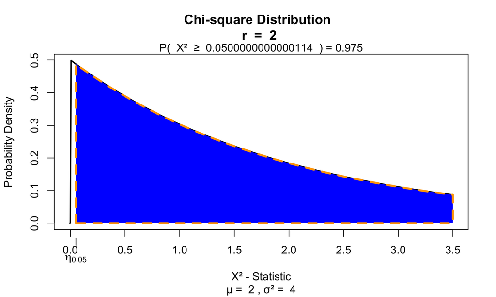

```r
visualize.chisq(F.r, df, section="upper")
```

## END

[@shklinkenberg](https://twitter.com/shklinkenberg)